# Module 1: Fish and heavy metal contaminants

### Comparing groups in the same plot

Using `ggplot()`, we can adjust the settings inside geoms to include both groups (in our case years) inside the same plot. Below are two different examples, a bozplot and a scatter plot with the year set to color. Look at the code below to see what is different.

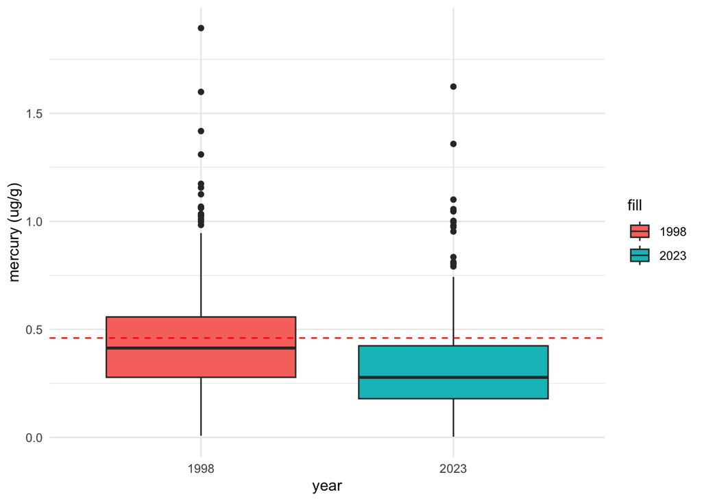

```r
# 1. boxplots
ggplot() +
  geom_boxplot(data=fish_1998, aes(x="1998", y=mercury, fill="1998")) +
  geom_boxplot(data=fish_2023, aes(x="2023", y=mercury, fill="2023")) +
  geom_hline(aes(yintercept=0.46), color="red", linetype="dashed") +
  labs(x="year", y="mercury (ug/g)") +
  theme_minimal()
```

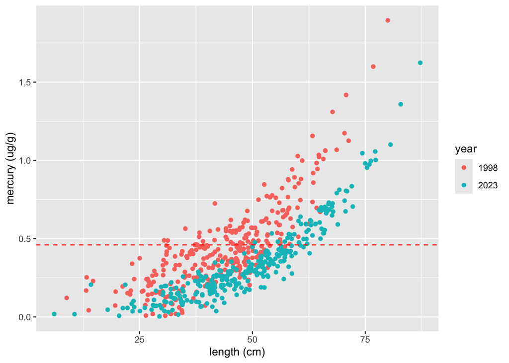

```r
# 2. scatter plot with color = year

ggplot() +
  geom_point(data=fish_1998, aes(x=length, y=mercury, color="1998")) +
  geom_point(data=fish_2023, aes(x=length, y=mercury, color="2023")) +
  geom_hline(aes(yintercept=0.46), color="red", linetype="dashed") +
  labs(color ="year", y="mercury (ug/g)", x="length (cm)")
```

**Class Questions:**

- How does the different ways of visualizing the data, as two separate plots and as different groups on the same plot, affect how we are able to interpret the data?
- Can you think of scenarios when it would be more useful to use one or the other?

### Lesson 1.5 Recap

In Lesson 1.5, we have reviewed:

- Reading in and previewing a data frame of the 2023 fish survey
- Calculating descriptive statistics
- Data visualization with `ggplot()`
- Comparing different groups in data visualization